# Tarea 3 — Proyecto R + Git + Excel

CA-0204 Herramientas de Ciencia de Datos I · II Ciclo 2026

Autor/a

Lemuel Méndez Hidalgo · C24750

Fecha de publicación

14 de noviembre de 2026

```
RESULTADO_1A = 28
RESULTADO_1B = 2025-01-20
RESULTADO_1C = 30
RESULTADO_2A = 0.0030
RESULTADO_2B = Aserrí
RESULTADO_2C = 0
RESULTADO_2D = Aserrí
RESULTADO_3A = 13995392964.17
RESULTADO_3B = 466164764.17
RESULTADO_3C = 24757259826.67
```

## 1 Ejercicio 1 — Alertas por ventana móvil

Para cada día $t$ se cuentan las transacciones $n_t$ y se comparan contra los 5 días **anteriores** (sin incluir el día $t$). El día tiene alerta si $n_t > \mu_t + k \cdot s_t$, con $k =$ 2.25. Los primeros 5 días no se evalúan.

Tabla 1: Primeros 5 días con alerta (parámetros personales)

| Fecha | Transacciones | Media | Desv. estándar | Umbral |
| --- | --- | --- | --- | --- |
| 2025-01-20 | 2 526 | 2 400.6 | 39.0 | 2 488.3 |
| 2025-01-27 | 2 445 | 2 375.2 | 24.2 | 2 429.7 |
| 2025-02-17 | 2 332 | 2 225.2 | 38.5 | 2 311.8 |
| 2025-03-01 | 3 475 | 2 244.8 | 49.1 | 2 355.3 |
| 2025-03-09 | 3 543 | 3 424.0 | 42.0 | 3 518.5 |

Con los parámetros personales (ventana = 5, k.alerta = 2.25) hay **28 días con alerta** y la primera ocurre el **2025-01-20**. Con los parámetros comunes (ventana = 7, k.alerta = 2) hay **30 días con alerta**.

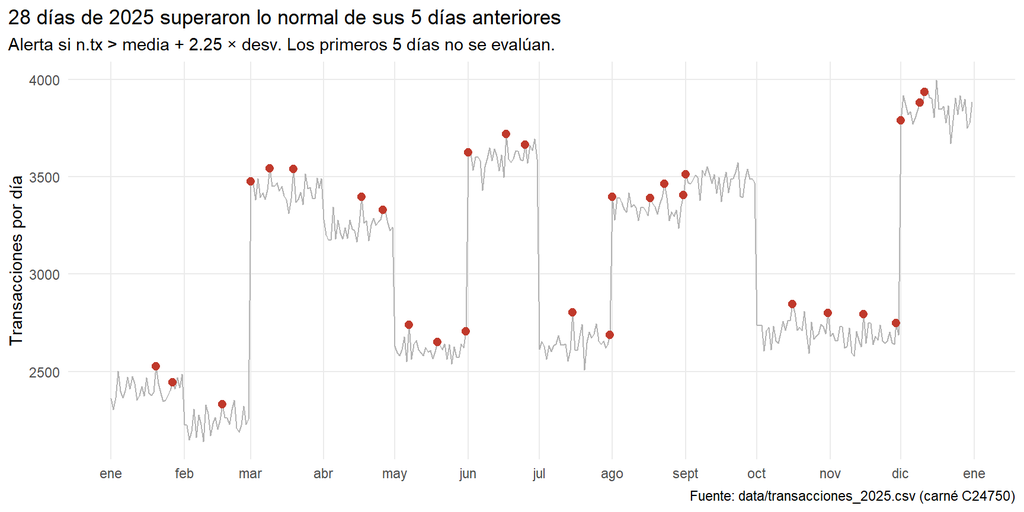

Figura 1: Transacciones diarias en 2025 y días con alerta (parámetros personales)

## 2 Ejercicio 2 — Ley de Benford por cantón

Para cada monto se toma el primer dígito $d$ y se compara la proporción observada $p_d$ contra la de Benford, $B_d = \log_{10}(1 + 1/d)$. La desviación absoluta media es $\text{MAD} = \frac{1}{9}\sum_{d=1}^{9} |p_d - B_d|$ y se clasifica con los cortes de Nigrini.

Tabla 2: Cinco cantones con mayor MAD en el canal personal

| Código | Cantón | Transacciones | MAD | Clase |
| --- | --- | --- | --- | --- |
| 106 | Aserrí | 446 | 0.0130 | conformidad marginal |
| 305 | Turrialba | 917 | 0.0118 | conformidad aceptable |
| 706 | Guácimo | 507 | 0.0113 | conformidad aceptable |
| 307 | Oreamuno | 865 | 0.0101 | conformidad aceptable |
| 503 | Santa Cruz | 553 | 0.0101 | conformidad aceptable |

En el canal **SINPE Móvil**, la MAD de todos los cantones juntos es **0.0030**. El cantón con mayor MAD es **Aserrí** y hay **0** cantones en no conformidad (MAD > 0,015). En el canal **Web** (común), el cantón con mayor MAD es **Aserrí**.

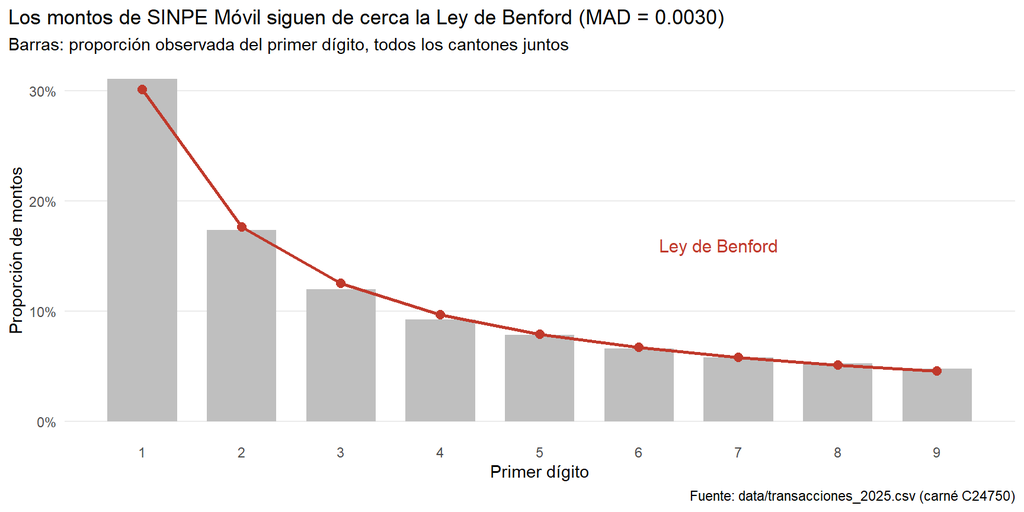

Figura 2: Proporción del primer dígito en el canal personal contra la Ley de Benford

**Conclusión:** los cinco cantones con mayor MAD tienen en promedio 658 transacciones, frente a una mediana de 2697; no parece fraude sino un efecto del tamaño de muestra, porque con pocos montos la proporción de cada dígito varía más por azar.

## 3 Ejercicio 3 — Valor acumulado con interés

Lo que entra por el canal **Sucursal** se deposita el último día de cada mes en una cuenta que paga una tasa efectiva anual de 8 %. La tasa mensual equivalente es $i_m = (1 + i)^{1/12} - 1 =$ 0.006434 y el valor al 31 de diciembre es $VA = \sum_{m=1}^{12} S_m (1 + i_m)^{12 - m}$.

Tabla 3: Monto mensual del canal y su factor de acumulación

| Mes | Monto (₡) | Factor |
| --- | --- | --- |
| 1 | 926 301 000 | 1.073096 |
| 2 | 766 634 100 | 1.066235 |
| 3 | 1 304 119 000 | 1.059419 |
| 4 | 1 199 547 100 | 1.052646 |
| 5 | 953 452 500 | 1.045917 |
| 6 | 1 351 553 800 | 1.039230 |
| 7 | 1 018 092 100 | 1.032587 |
| 8 | 1 237 430 500 | 1.025986 |
| 9 | 1 297 103 200 | 1.019427 |
| 10 | 1 030 308 500 | 1.012909 |
| 11 | 995 328 900 | 1.006434 |
| 12 | 1 449 357 500 | 1.000000 |

El valor acumulado al 31 de diciembre es **₡13995392964.17** y los intereses ganados son **₡466164764.17**. Con la tasa común (6 %) y el canal **App**, el valor acumulado es **₡24757259826.67**.

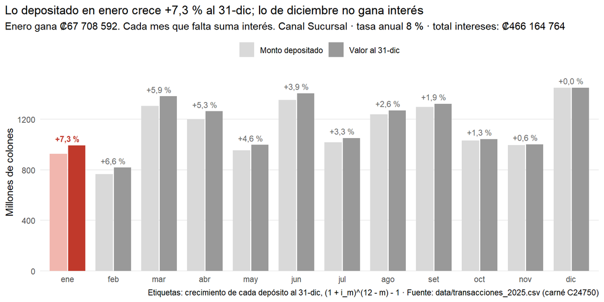

Figura 3: Monto depositado cada mes y su valor acumulado al 31 de diciembre